# survival lecture 5

Steve Simon

May 27, 2018

Lecture 5. Parametric models. Parametric models provide an alternative analysis to the Cox proportional hazards model. You’ll compare the hazard function for various popular survival distributions and understand the advantages and disadvantages of a parametric approach to survival. You’ll fit parametric models and interpret the coefficients.

```r
library(broom)
library(dplyr)
```

```r
library(ggplot2)
library(magrittr)
library(survival)
library(tidyr)
fn <- "~/survival-models/bin/whas100.RData"
load(fn)
whas100$time_yrs <- whas100$lenfol / 365.25
head(whas100)
```

```
##   id  admitdate    foldate los lenfol fstat age gender      bmi  time_yrs
## 1  1 1995-03-13 1995-03-19   4      6  Dead  65   Male 31.38134 0.0164271
## 2  2 1995-01-14 1996-01-23   5    374  Dead  88 Female 22.65790 1.0239562
## 3  3 1995-02-17 2001-10-04   5   2421  Dead  77   Male 27.87892 6.6283368
## 4  4 1995-04-07 1995-07-14   9     98  Dead  81 Female 21.47878 0.2683094
## 5  5 1995-02-09 1998-05-29   4   1205  Dead  78   Male 30.70601 3.2991102
## 6  6 1995-01-16 2000-09-11   7   2065  Dead  82 Female 26.45294 5.6536619
```

```r
whas100_surv <- Surv(whas100$time_yrs, whas100$fstat=="Dead")
```

Before you fit the exponential and Weibull regression models, fit a Kaplan-Meier curve.

```r
par(mar=c(2.6, 2.6, 0.6, 0.6))
km_overall <- survfit(Surv(whas100$time_yrs, whas100$fstat)~1)
exp_null_model <- survreg(whas100_surv~1, dist="exponential")
summary(exp_null_model)
```

```
##
## Call:
## survreg(formula = whas100_surv ~ 1, dist = "exponential")
##             Value Std. Error    z        p
## (Intercept)  2.09       0.14 14.9 2.35e-50
##
## Scale fixed at 1
##
## Exponential distribution
## Loglik(model)= -157.6   Loglik(intercept only)= -157.6
## Number of Newton-Raphson Iterations: 5
## n= 100
```

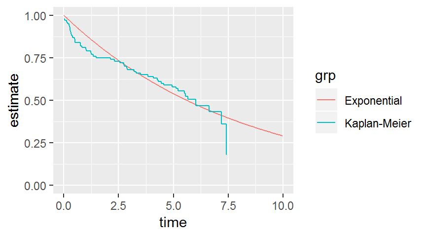

```r
pct <- (1:999)/1000

exp_null_model %>%
  predict(
    newdata=data.frame(one=1),
    type="quantile",
    p=pct)                     %>%
  data.frame                   %>%
  set_names("time")            %>%
  mutate(estimate=rev(pct))    %>%
  mutate(grp="Exponential")    %>%
  filter(time<=10)             -> exp_survival

km_overall                     %>%
  tidy                         %>%
  mutate(estimate=1-estimate)  %>%
  mutate(grp="Kaplan-Meier")   %>%
  bind_rows(exp_survival)      -> combined_survivals

combined_survivals             %>%
  ggplot(aes(time, estimate))   +
    expand_limits(y=0)          +
    geom_step(aes(color=grp))
```

You can also compare the cumulative hazard functions.

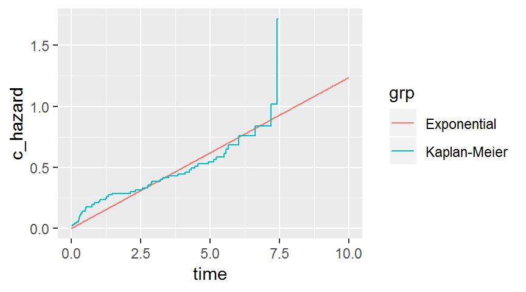

```r
par(mar=c(2.6, 2.6, 0.6, 0.6))
combined_survivals                %>%
  mutate(c_hazard=-log(estimate)) %>%
  ggplot(aes(time, c_hazard))      +
    geom_step(aes(color=grp))
```

```r
par(mar=c(2.6, 2.6, 0.6, 0.6))
whas100$age_c=whas100$age-mean(whas100$age)
whas100$bmi_c=whas100$bmi-mean(whas100$bmi)
whas100$i_female=as.numeric(whas100$gender=="Female")
exp_model <- survreg(
  whas100_surv~i_female*age_c+bmi_c,
  data=whas100,
  dist="exponential")
summary(exp_model)
```

```
##
## Call:
## survreg(formula = whas100_surv ~ i_female * age_c + bmi_c, data = whas100,
##     dist = "exponential")
##                  Value Std. Error     z        p
## (Intercept)     2.2866     0.2014 11.35 7.01e-30
## i_female       -0.5367     0.3159 -1.70 8.93e-02
## age_c          -0.0532     0.0157 -3.39 7.04e-04
## bmi_c           0.0935     0.0376  2.49 1.28e-02
## i_female:age_c  0.0498     0.0241  2.06 3.94e-02
##
## Scale fixed at 1
##
## Exponential distribution
## Loglik(model)= -143.4   Loglik(intercept only)= -157.6
##  Chisq= 28.25 on 4 degrees of freedom, p= 1.1e-05
## Number of Newton-Raphson Iterations: 5
## n= 100
```

```r
cox_model <- coxph(
  whas100_surv~i_female*age_c+bmi_c,
  data=whas100)
summary(cox_model)
```

```
## Call:
## coxph(formula = whas100_surv ~ i_female * age_c + bmi_c, data = whas100)
##
##   n= 100, number of events= 51
##
##                    coef exp(coef) se(coef)      z Pr(>|z|)
## i_female        0.49738   1.64441  0.31743  1.567 0.117140
## age_c           0.05399   1.05547  0.01553  3.477 0.000507 ***
## bmi_c          -0.08738   0.91633  0.03724 -2.346 0.018970 *
## i_female:age_c -0.05369   0.94773  0.02438 -2.202 0.027652 *
## ---
## Signif. codes:  0 '***' 0.001 '**' 0.01 '*' 0.05 '.' 0.1 ' ' 1
##
##                exp(coef) exp(-coef) lower .95 upper .95
## i_female          1.6444     0.6081    0.8827    3.0635
## age_c             1.0555     0.9474    1.0238    1.0881
## bmi_c             0.9163     1.0913    0.8518    0.9857
## i_female:age_c    0.9477     1.0552    0.9035    0.9941
##
## Concordance= 0.696  (se = 0.043 )
## Rsquare= 0.229   (max possible= 0.985 )
## Likelihood ratio test= 26.01  on 4 df,   p=3.15e-05
## Wald test            = 21.63  on 4 df,   p=0.0002373
## Score (logrank) test = 23.48  on 4 df,   p=0.0001017
```

```r
exp_coef <- tidy(exp_model)
bmi_coef <- exp(exp_coef[exp_coef$term=="bmi_c", "estimate"])
age_m_coef <- exp(exp_coef[exp_coef$term=="age_c", "estimate"])
age_f_coef <- exp(exp_coef[exp_coef$term=="age_c", "estimate"]+
  exp_coef[exp_coef$term=="i_female:age_c", "estimate"])
```

Each unit increase in BMI shifts the survival percentiles by a factor of exp(0.093) = 1.098. A five unit shift in BMI shifts the survival percentiles by 1.098^5 = 1.596.

Because of the interaction, the effect of age is different for men and women. For men, a one year increase in age will shift the survival percentiles by a factor of exp(-0.053) = 0.948.

For women, a one year increase in age will shift the survival percentiles by a factor of exp(-0.053 + 0.05) = 0.997.

This may look quite different than the model we used for Kaplan-Meier curves and the Cox proportional hazards model, but it actually is not. The hazard function is

$h(t, x, \beta_0, \beta_1)=e^{-(\beta_0+\beta_1 x)}$.

Notice that the hazard is constant with respect to t. The baseline hazard, the hazard when X=0 is

$h_0(t)=e^{-\beta_0}$

The hazard ratio for a subject with $x=x_1$ compared to a subject with $x=x_2$ is

$e^{-\beta_1 (x_1-x_2)}$

```r
par(mar=c(2.6, 2.6, 0.6, 0.6))
weibull_null_model <- survreg(whas100_surv~1, dist="weibull")
summary(weibull_null_model)
```

```
##
## Call:
## survreg(formula = whas100_surv ~ 1, dist = "weibull")
##             Value Std. Error     z        p
## (Intercept) 2.268      0.212 10.71 8.75e-27
## Log(scale)  0.312      0.129  2.41 1.61e-02
##
## Scale= 1.37
##
## Weibull distribution
## Loglik(model)= -154.3   Loglik(intercept only)= -154.3
## Number of Newton-Raphson Iterations: 5
## n= 100
```

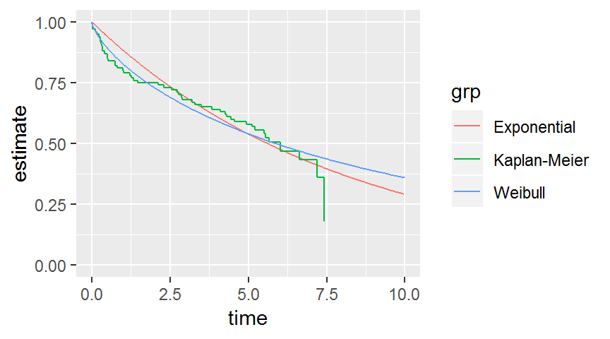

```r
pct <- (1:999)/1000

weibull_null_model %>%
  predict(
    newdata=data.frame(one=1),
    type="quantile",
    p=pct)                     %>%
  data.frame                   %>%
  set_names("time")            %>%
  mutate(estimate=rev(pct))    %>%
  mutate(grp="Weibull")        %>%
  filter(time<=10)             -> weibull_survival

combined_survivals             %>%
  bind_rows(weibull_survival)  -> combined_survivals

combined_survivals             %>%
  ggplot(aes(time, estimate))   +
    expand_limits(y=0)          +
    geom_step(aes(color=grp))
```

```r
weibull_model <- survreg(
  whas100_surv~i_female*age_c+bmi_c,
  data=whas100,
  dist="weibull")
summary(weibull_model)
```

```
##
## Call:
## survreg(formula = whas100_surv ~ i_female * age_c + bmi_c, data = whas100,
##     dist = "weibull")
##                  Value Std. Error     z        p
## (Intercept)     2.4610     0.2746  8.96 3.17e-19
## i_female       -0.6522     0.3999 -1.63 1.03e-01
## age_c          -0.0639     0.0206 -3.10 1.94e-03
## bmi_c           0.1055     0.0465  2.27 2.32e-02
## i_female:age_c  0.0592     0.0304  1.94 5.18e-02
## Log(scale)      0.2254     0.1242  1.81 6.95e-02
##
## Scale= 1.25
##
## Weibull distribution
## Loglik(model)= -141.6   Loglik(intercept only)= -154.3
##  Chisq= 25.36 on 4 degrees of freedom, p= 4.3e-05
## Number of Newton-Raphson Iterations: 5
## n= 100
```

```r
coef_w <- tidy(weibull_model)
coef_w
```

```
##             term    estimate  std.error statistic      p.value
## 1    (Intercept)  2.46098180 0.27458460  8.962563 3.172169e-19
## 2       i_female -0.65217400 0.39990465 -1.630824 1.029275e-01
## 3          age_c -0.06394027 0.02062777 -3.099718 1.937049e-03
## 4          bmi_c  0.10551029 0.04647553  2.270233 2.319345e-02
## 5 i_female:age_c  0.05915426 0.03042177  1.944471 5.183863e-02
## 6     Log(scale)  0.22544000 0.12421784  1.814876 6.954293e-02
##        conf.low   conf.high
## 1  1.9228058866  2.99915772
## 2 -1.4359727129  0.13162472
## 3 -0.1043699537 -0.02351059
## 4  0.0144199192  0.19660067
## 5 -0.0004713115  0.11877982
## 6            NA          NA
```

```r
log_scale <- coef_w[coef_w$term=="Log(scale)", "estimate"]
std_error <- coef_w[coef_w$term=="Log(scale)", "std.error"]
ci_lower <- exp(log_scale-1.96*std_error)
ci_upper <- exp(log_scale+1.96*std_error)
```

The 95% confidence interval for the scale parameter is exp(0.225 +/- 1.96*0.124) or 0.982 to 1.598.

Save everything for possible later re-use.

```r
save.image("~/survival-models/bin/survival-lecture-5.RData")
```